# Support Vector Machine

Author

Simone Brazzi

# 1 Import

```r
library(tidyverse, verbose = FALSE)
library(ggplot2)
library(reticulate)

# renv::use_python("/Users/simonebrazzi/venv/ml/bin/python")
```

# 2 Theory

This type of model is useful whene there are few data.

**SVC** is a type of supervised ML classificator. It maximize the distance between classes. It is useful whene there are overlaps.

THE SVM maximize the distance between the support vectors and the decision boundary.

## 2.1 Maximal margin Classifier

This is a type of classifier which uses the 2 observation of the 2 classes which are **closer**. It is weak to outliers. It works correctly if values are distant.

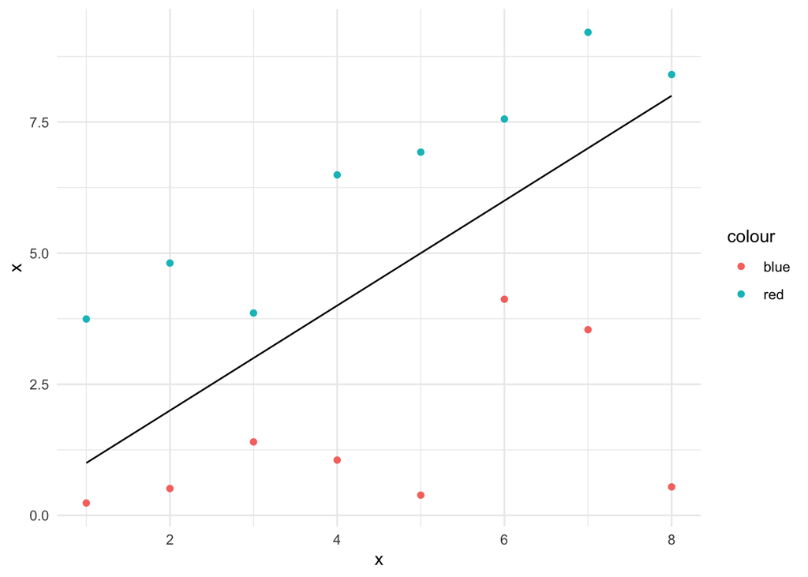

```r
set.seed(42)

x <- seq(1, 8, 1)

y1 <- x + runif(8, 0, 3)
y2 <- x - runif(8, 0.5, x - 0.1)


df <- tibble(
  x = x,
  y1 = y1,
  y2 = y2
)

ggplot(df) +
  geom_line(aes(x = x, y = x)) +
  geom_point(aes(x = x, y = y1, colour = "red")) +
  geom_point(aes(x = x, y = y2, colour = "blue")) +
  theme_minimal()
```

## 2.2 SVC

It allows **soft margins**, meaning it accept mistakes. The margins are created using **support vectors** (values). How are they choose? This happens during the training, choosing the best values which led to less mistakes.

The logistic regression learns from the most rappresentative examples. The SVM learns from the most promiscuous examples.

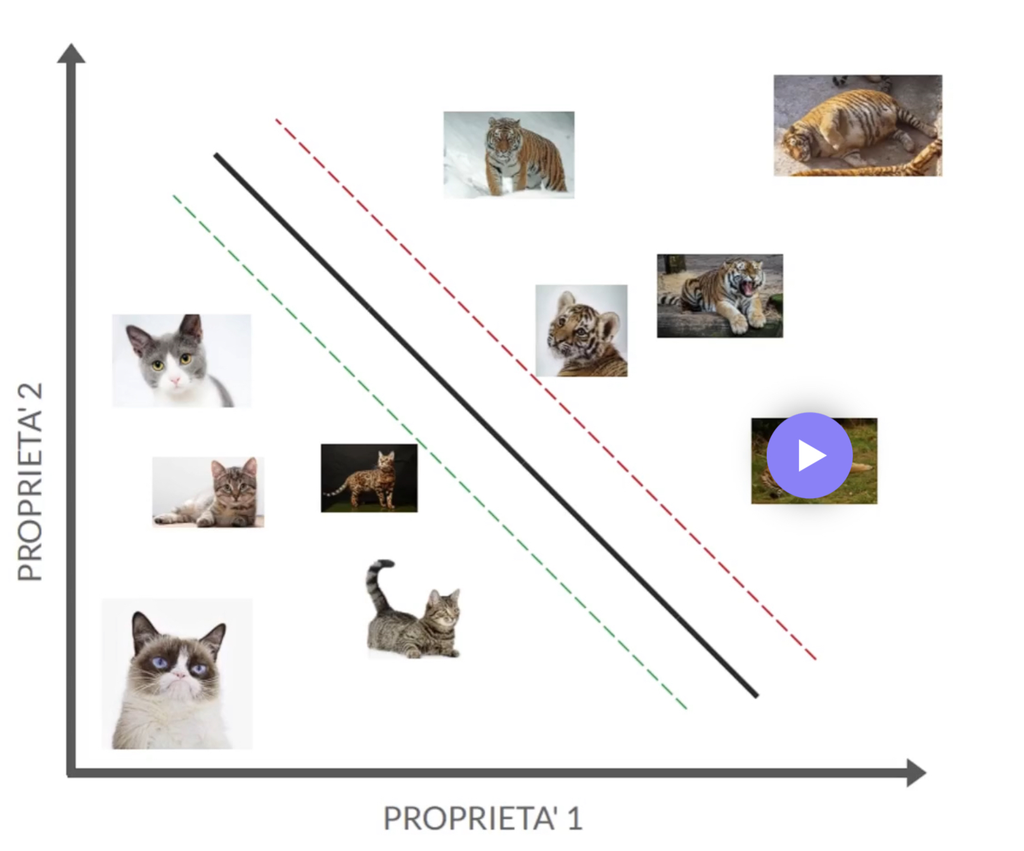

Outliers, meaning cats which are cats and tiger which seems tiger, will not affect the model.

## 2.3 SVC training

It requires deep knowledg of optimization algorithm. Just bear in mind that it **calculate the similarity between each example in the train set**.

## 2.4 PROs

- Robust to outliers.
- Good results with few data
- Efficient with high dimensionality spaces.
- Low computational requirements.

Still used for face detection in photography.

SVC are particularly useful when the number of features is greater then the number of observations.

Use it when:

- Lots of outliers.
- Few observations.
- Lots of features.
- Low computational power.

Avoid it when:

- Lots of noise.
- Lots of observations.

# 3 SVC and Non Linear Relations

Even if the SVC are linear models, they can be used with non linear relations with the SVM. SVM projects data in a higher dimensional space and looks for the best SVC in this space.

**Note**

Mapping could be computational demanding or impossible! There is still a solution.

# 4 Kernel and Kernel Trick

The kernel function measures the similarity/distance between 2 observations or classes.

$$k(x, z) = \langle \phi(x), \phi(x) \rangle$$

The **kernel trick** lets calculate the similarity in a higher dimensional space, mantaining the observation in the original dimensional space.

$x_i$ features vector. $y_i$ label. $(x_i, y_i)$

The kernel trick maps data in an higher dimension space with the function $k(x^a, x^b)$. This mapping gets the linear separation in the new feature space, even if data are not in the original one.

The function *k* calculates the **scalar product** between vectors $x^a$ and $x^b$ in the higher dimensional space. This product is a measure of similarity of $x^a$ and $x^b$ after the projection. The **cosine similarity** is calculated using the scalar product.

**Note**

checks documents

Rewriting the optimization problem as a scalar product between the vectors of the features:

$$\max \limits_\alpha \sum_{i=1}^{N}{a_i} - \frac{1}{2}\sum_{i, j = 1}^{N}{y_iy_j\alpha_i\alpha_jk(x_i,x_j)}$$
limited to

$$\sum_{i=1}^{N}{\alpha_iy_i} = 0, \ (0 \leq \alpha_i \leq C)\ for (i = 1, ..., N)$$

**Note**

The optimization depends only on the combinations of data between the scalar product

$$k(x_i, x_j)$$

and not on the values of the features $x_i$ and $x_j$. This means we don’t need to know explicitly the mapping function or to calculate the new features in the new space.

The mapping is not required, is just simulated: this is the trick!

The linear separation in the new space depend only on the similarity after the projection. We can find the support vectors and define the separation hyperplane using only the scalar product defined with the kernel.

## 4.1 Type of kernels

It is an hyperparameter to be defined with CV.

### 4.1.1 Linear

Simpler, used when data are already linearly separable in the original space.

$$K(a, b) = \langle a, b \rangle$$

### 4.1.2 Polinomial kernel

Data can be separated by a curved hyperplane. It can model non linear relations between the features.

$$K(a, b) = (\gamma \langle a, b \rangle + r)^d$$

### 4.1.3 Gaussian kernel or Radial basis function

It can model differents separation forms because it can simulate on an infinite hyperplanes.

$$K(a, b) = e^{- \gamma ||a-b||^2}$$

It works best with **non linear separable** data.

### 4.1.4 Sigmoidal kernel

It is useful if the data coould be modeled after a sigmoidal function.

$$K(a, b) = tanh(\gamma \langle a, b \rangle + r)$$

**Note**

$\gamma$ is an hyperparameter which represent the influence of the width of the top of the kernel function.

Simply put, controls how much each observation impacts on the nearby ones in the separation decision.

It lets balance **bias** and **variance**, so under and over fitting.

# 5 Practice

## 5.1 Create a Maximal Margin Separating Hyperplane

```python
import matplotlib.pyplot as plt
from sklearn.datasets import make_blobs

random_seed = 6
```

```python
x, y = make_blobs(
  n_samples=40,
  centers=2,
  random_state=random_seed
)
```

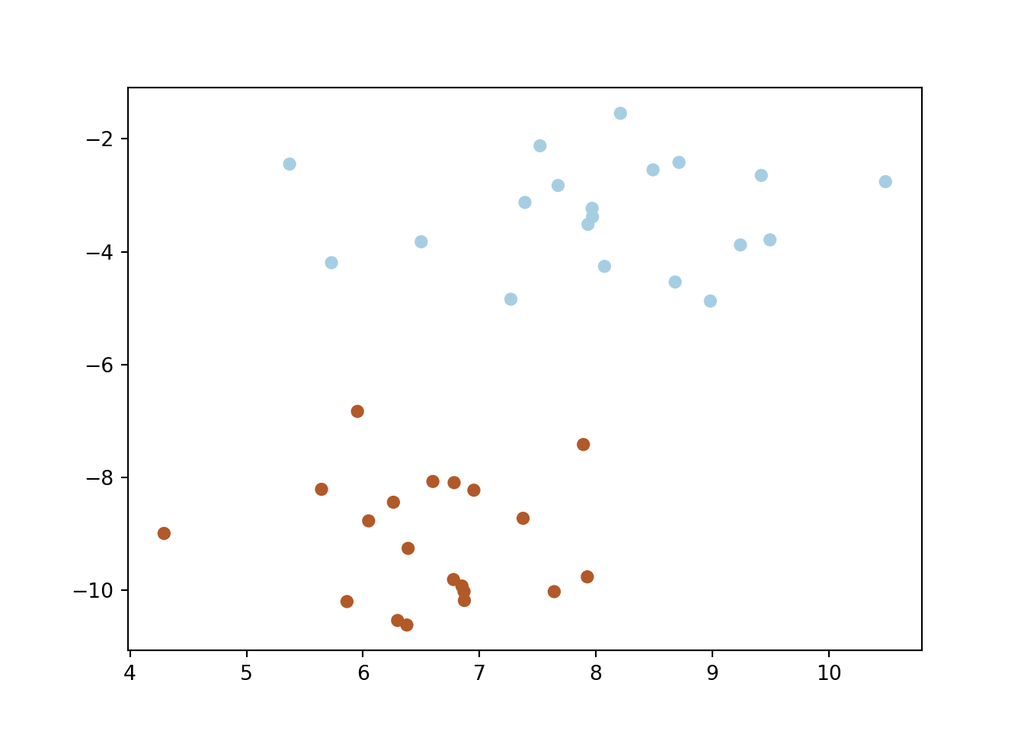

```python
plt.scatter(x[:, 0], x[:, 1], c=y, s=30, cmap=plt.cm.Paired)
plt.show()
```

We have to find the hyperplane which best separate these points. We are going to use an SVM, because the MMC is too simple and it is not implemented.

```python
from sklearn.svm import SVC

svc = SVC(kernel="linear")

svc.fit(x, y)
```

```
SVC(kernel='linear')
```

## 5.2 Soft margins

Lets plot the soft margins.

```python
from sklearn.inspection import DecisionBoundaryDisplay

plt.close()
plt.scatter(x[:, 0], x[:, 1], c=y, s=30, cmap=plt.cm.Paired)
ax = plt.gca()
DecisionBoundaryDisplay.from_estimator(
  svc,
  x,
  ax=ax,
  alpha=0.5
  )
```

```
<sklearn.inspection._plot.decision_boundary.DecisionBoundaryDisplay object at 0x15ae87d10>
```

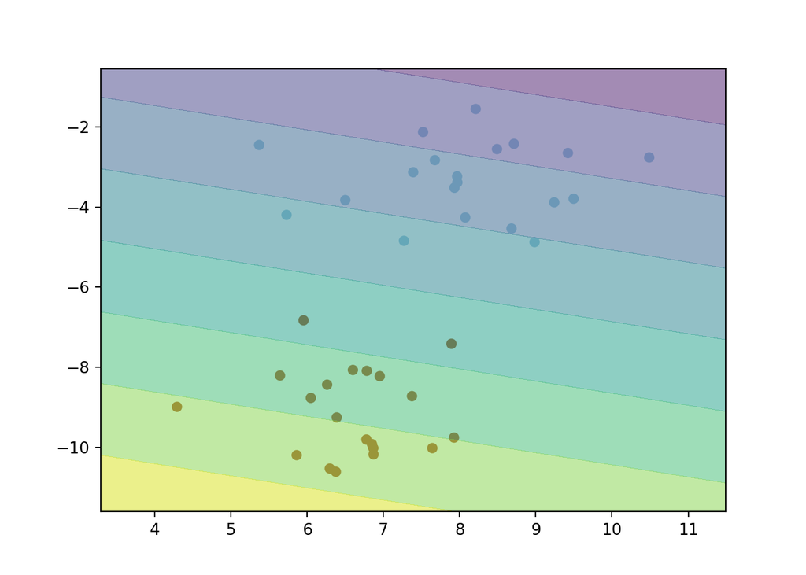

```python
plt.show()
```

But we want just the margins! This graph shows the probability of a class.

```python
plt.close()
plt.scatter(x[:, 0], x[:, 1], c=y, s=30, cmap=plt.cm.Paired)
ax = plt.gca()
DecisionBoundaryDisplay.from_estimator(
  svc,
  x,
  ax=ax,
  alpha=0.5,
  plot_method="contour",
  levels=[-1, 0, 1],
  linestyles=["--", "-", "--"],
  colors="k"
  )
```

```
<sklearn.inspection._plot.decision_boundary.DecisionBoundaryDisplay object at 0x14652cd50>
```

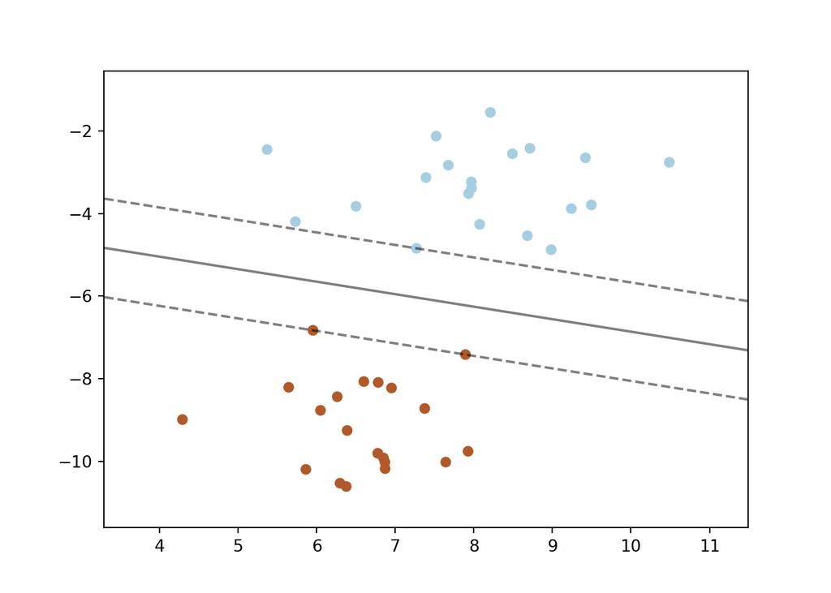

```python
plt.show()
```

These are the soft margins. The support vectors are the observatoins with dashed lines.

It is possible to get the (x, y) coordinates of the support vectors.

```python
svc.support_vectors_
```

```
array([[ 7.27059007, -4.84225716],
       [ 5.95313618, -6.82945967],
       [ 7.89359985, -7.41655113]])
```

So we can do

```python
plt.close()
plt.scatter(x[:, 0], x[:, 1], c=y, s=30, cmap=plt.cm.Paired)
ax = plt.gca()
DecisionBoundaryDisplay.from_estimator(
  svc,
  x,
  ax=ax,
  alpha=0.5,
  plot_method="contour",
  levels=[-1, 0, 1],
  linestyles=["--", "-", "--"],
  colors="k"
  )
```

```
<sklearn.inspection._plot.decision_boundary.DecisionBoundaryDisplay object at 0x15d38ca90>
```

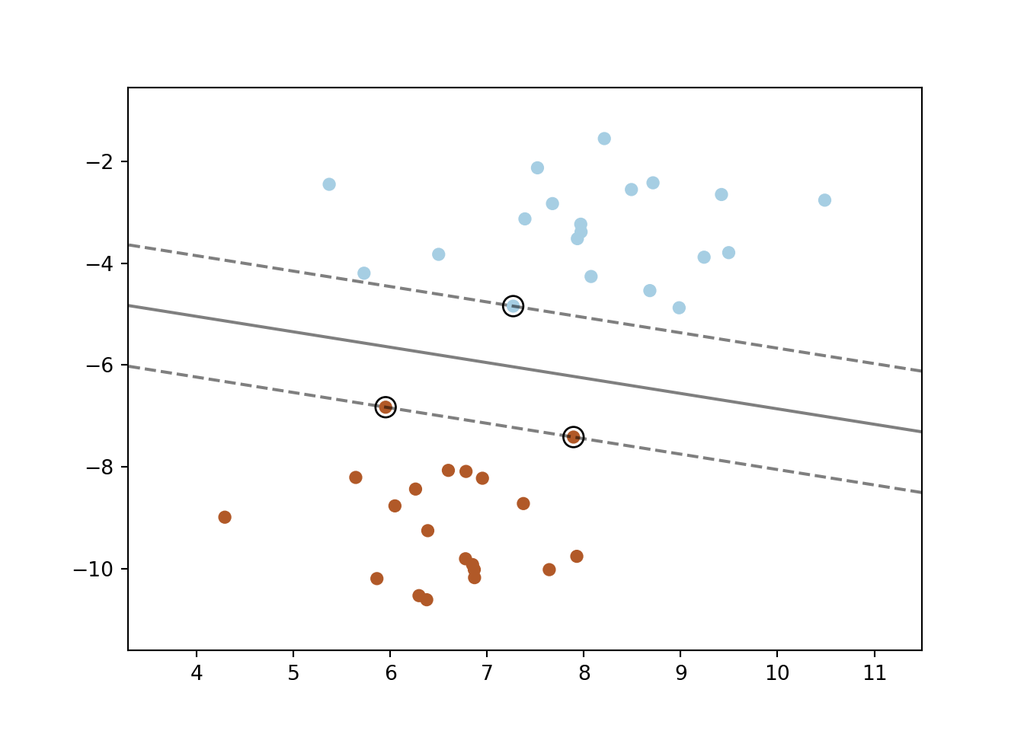

```python
ax.scatter(
  svc.support_vectors_[:, 0],
  svc.support_vectors_[:, 1],
  s=100,
  linewidth=1,
  facecolors="none",
  edgecolor="k"
)

plt.show()
```

This is our plot to visualize the SVC model. It maximize the margin between these two classes. This was easy, because there are not overlaps.

## 5.3 Linear SVM

```python
import numpy as np
import pandas as pd
import matplotlib.pyplot as plt
from sklearn.inspection import DecisionBoundaryDisplay
from sklearn.datasets import make_classification
from sklearn.model_selection import train_test_split
from sklearn.metrics import classification_report

from sklearn.svm import LinearSVC

random_seed = 0
```

```python
def plot_data(data):

  plt.close()

  x, y = data

  plt.scatter(x[:, 0], x[:, 1], c=y, s=30, cmap=plt.cm.Paired)

  plt.show()


def plot_softmargin(model, data, show_sv=False):

  plt.close()
  x, y = data
  plt.scatter(x[:, 0], x[:, 1], c=y, s=30, cmap=plt.cm.Paired)
  ax = plt.gca()
  DecisionBoundaryDisplay.from_estimator(
    model,
    x,
    ax=ax,
    alpha=0.5,
    plot_method="contour",
    levels=[-1, 0, 1],
    linestyles=["--", "-", "--"],
    colors="k"
    )

  if show_sv == True:
    ax.scatter(
      model.support_vectors_[:, 0],
      model.support_vectors_[:, 1],
      s=100,
      linewidth=1,
      facecolors="none",
      edgecolor="k"
      )
  plt.show()

def print_classification_report(model, data):

  x, y = data

  ypred = model.predict(x)

  cr = classification_report(ypred, y)
  print(cr)
```

```python
x, y = make_classification(
  n_samples=100,
  n_features=2,
  n_informative=2,
  n_redundant=0,
  n_repeated=0,
  n_classes=2,
  random_state=random_seed
)
```

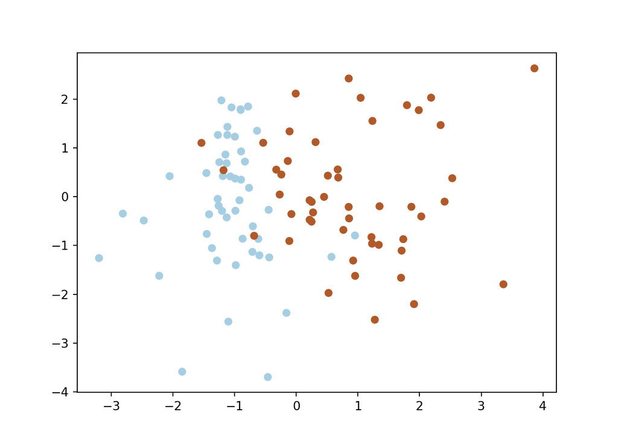

```python
plot_data((x, y))
```

Let see how the SVM can get the hyperplane which can handle this overlap.

```python
xtrain, xtest, ytrain, ytest = train_test_split(
  x, y,
  test_size=.3,
  random_state=random_seed
)

svc = LinearSVC()
svc.fit(xtrain, ytrain)
```

```
LinearSVC()
```

```python
print_classification_report(svc, (xtest, ytest))
```

```
              precision    recall  f1-score   support

           0       1.00      0.89      0.94        18
           1       0.86      1.00      0.92        12

    accuracy                           0.93        30
   macro avg       0.93      0.94      0.93        30
weighted avg       0.94      0.93      0.93        30
```

Lets plot the hyperplane.

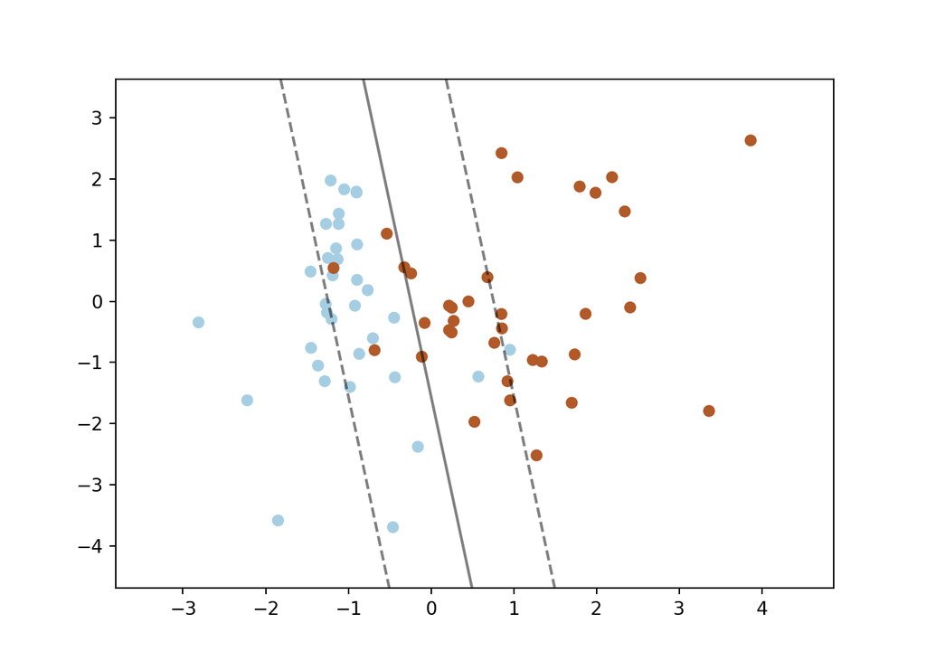

```python
plt.close()
plot_softmargin(svc, (xtrain, ytrain), show_sv=False)
```